# R Notebook

```r
library(ggplot2)
library(reshape2)
```

```r
loan = read.csv("./loan.csv")
```

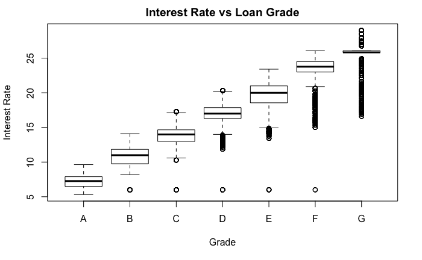

```r
boxplot(loan$int_rate~loan$grade, main = "Interest Rate vs Loan Grade", xlab = "Grade", ylab = "Interest Rate")
```

```r
NAs <- loan[,colSums(is.na(loan)) >  nrow(loan)*.9]
colnames(NAs)
```

```
 [1] "annual_inc_joint"   "dti_joint"          "open_acc_6m"        "open_il_6m"         "open_il_12m"        "open_il_24m"
 [7] "mths_since_rcnt_il" "total_bal_il"       "il_util"            "open_rv_12m"        "open_rv_24m"        "max_bal_bc"
[13] "all_util"           "inq_fi"             "total_cu_tl"        "inq_last_12m"
```

```r
levels(loan$loan_status)
```

```
 [1] "Charged Off"                                         "Current"
 [3] "Default"                                             "Does not meet the credit policy. Status:Charged Off"
 [5] "Does not meet the credit policy. Status:Fully Paid"  "Fully Paid"
 [7] "In Grace Period"                                     "Issued"
 [9] "Late (16-30 days)"                                   "Late (31-120 days)"
```

Since we want to predict “Default” or “Charged Off” vs “Fully Paid”, we can ignore the others for the time being.

```r
new_data = loan[loan$loan_status %in% c("Default", "Charged Off", "Fully Paid"),]
new_data$loan_status = droplevels(new_data$loan_status, c("Current", "Does not meet the credit policy. Status:Charged Off", "Does not meet the credit policy. Status:Fully Paid", "In Grace Period", "Issued", "Late (16-30 days)", "Late (31-120 days)"))
dim(new_data)
```

```
[1] 254190     74
```

```r
new_data$loan_status_numeric = ifelse(new_data$loan_status == "Fully Paid", 0, 1)
```

```r
levels(new_data$loan_status) = c("Default", "Default", "Fully Paid")
levels(new_data$loan_status)
```

```
[1] "Default"    "Fully Paid"
```

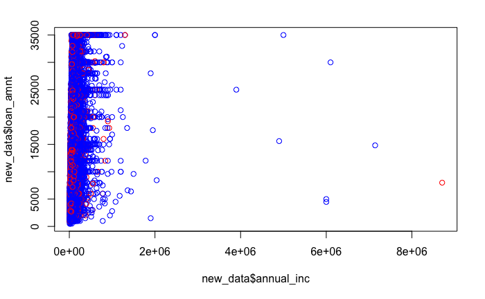

```r
plot(new_data$annual_inc, new_data$loan_amnt, col = ifelse(new_data$loan_status == "Fully Paid", "blue", "red"))
```

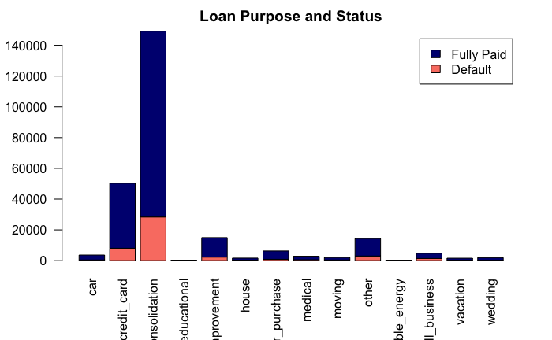

```r
counts <- table(new_data$loan_status, new_data$purpose)
barplot(counts, main="Loan Purpose and Status",
  col=c("salmon", "navy"),
    legend = rownames(counts), las = 2)
```

```r
nrow(new_data[new_data$loan_status_numeric == 1,]) / nrow(new_data)
```

```
[1] 0.1828042
```

```r
nrow(new_data[new_data$loan_status_numeric == 0,]) / nrow(new_data)
```

```
[1] 0.8171958
```

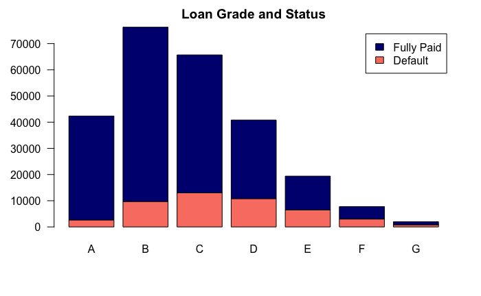

```r
counts <- table(new_data$loan_status, new_data$grade)
barplot(counts, main="Loan Grade and Status",
  col=c("salmon", "navy"),
    legend = rownames(counts), las = 1)
```

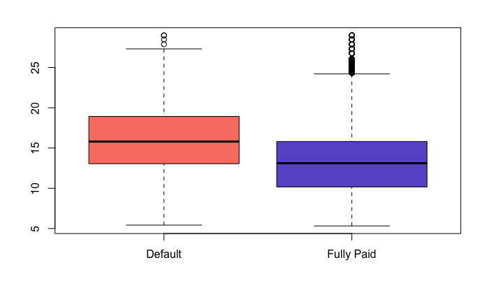

```r
boxplot(new_data$int_rate ~ new_data$loan_status, col = c("salmon", "slateblue"))
```

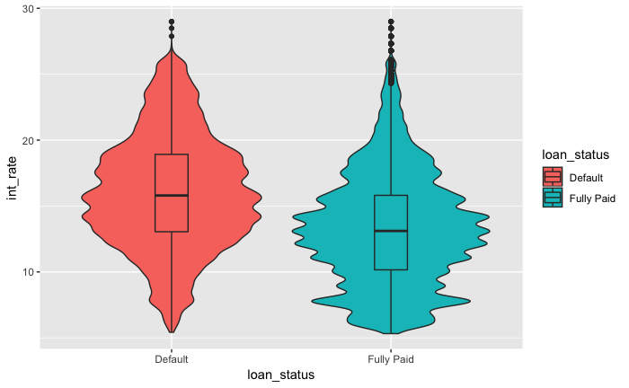

```r
p <- ggplot(new_data, aes(x=loan_status, y=int_rate, fill=loan_status)) + geom_violin() + geom_boxplot(width=0.15)
p
```

```r
numerics = new_data[,unlist(lapply(new_data, is.numeric))]
cormat <- round(cor(numerics),2)
```

```
the standard deviation is zero
```

```r
head(cormat)
```

```
                  id member_id loan_amnt funded_amnt funded_amnt_inv int_rate installment annual_inc  dti delinq_2yrs inq_last_6mths
id              1.00      1.00      0.07        0.08            0.08     0.05        0.05       0.04 0.12        0.06          -0.04
member_id       1.00      1.00      0.07        0.08            0.09     0.05        0.05       0.04 0.12        0.06          -0.04
loan_amnt       0.07      0.07      1.00        1.00            0.99     0.21        0.96       0.33 0.05        0.01           0.01
funded_amnt     0.08      0.08      1.00        1.00            0.99     0.21        0.96       0.33 0.05        0.01           0.01
funded_amnt_inv 0.08      0.09      0.99        0.99            1.00     0.22        0.95       0.33 0.06        0.01           0.01
int_rate        0.05      0.05      0.21        0.21            0.22     1.00        0.20      -0.03 0.17        0.09           0.22
                mths_since_last_delinq mths_since_last_record open_acc pub_rec revol_bal revol_util total_acc out_prncp out_prncp_inv
id                                  NA                     NA     0.11    0.14      0.02         NA      0.11      0.07          0.07
member_id                           NA                     NA     0.11    0.14      0.02         NA      0.11      0.07          0.07
loan_amnt                           NA                     NA     0.20   -0.08      0.33         NA      0.23      0.05          0.05
funded_amnt                         NA                     NA     0.20   -0.07      0.33         NA      0.23      0.05          0.05
funded_amnt_inv                     NA                     NA     0.21   -0.07      0.33         NA      0.23      0.05          0.05
int_rate                            NA                     NA     0.04    0.08      0.02         NA     -0.01      0.04          0.04
                total_pymnt total_pymnt_inv total_rec_prncp total_rec_int total_rec_late_fee recoveries collection_recovery_fee
id                    -0.01            0.00            0.06         -0.26              -0.04      -0.04                   -0.01
member_id             -0.01            0.00            0.06         -0.26              -0.04      -0.04                   -0.01
loan_amnt              0.84            0.84            0.78          0.64               0.05       0.18                    0.13
funded_amnt            0.84            0.84            0.78          0.64               0.05       0.18                    0.13
funded_amnt_inv        0.84            0.84            0.78          0.63               0.04       0.18                    0.12
int_rate               0.12            0.13            0.03          0.40               0.06       0.18                    0.12
                last_pymnt_amnt collections_12_mths_ex_med mths_since_last_major_derog policy_code annual_inc_joint dti_joint
id                         0.32                         NA                          NA          NA               NA        NA
member_id                  0.32                         NA                          NA          NA               NA        NA
loan_amnt                  0.58                         NA                          NA          NA               NA        NA
funded_amnt                0.58                         NA                          NA          NA               NA        NA
funded_amnt_inv            0.58                         NA                          NA          NA               NA        NA
int_rate                   0.12                         NA                          NA          NA               NA        NA
                acc_now_delinq tot_coll_amt tot_cur_bal open_acc_6m open_il_6m open_il_12m open_il_24m mths_since_rcnt_il total_bal_il
id                        0.03           NA          NA          NA         NA          NA          NA                 NA           NA
member_id                 0.03           NA          NA          NA         NA          NA          NA                 NA           NA
loan_amnt                 0.01           NA          NA          NA         NA          NA          NA                 NA           NA
funded_amnt               0.01           NA          NA          NA         NA          NA          NA                 NA           NA
funded_amnt_inv           0.01           NA          NA          NA         NA          NA          NA                 NA           NA
int_rate                  0.03           NA          NA          NA         NA          NA          NA                 NA           NA
                il_util open_rv_12m open_rv_24m max_bal_bc all_util total_rev_hi_lim inq_fi total_cu_tl inq_last_12m loan_status_numeric
id                   NA          NA          NA         NA       NA               NA     NA          NA           NA               -0.03
member_id            NA          NA          NA         NA       NA               NA     NA          NA           NA               -0.03
loan_amnt            NA          NA          NA         NA       NA               NA     NA          NA           NA                0.06
funded_amnt          NA          NA          NA         NA       NA               NA     NA          NA           NA                0.06
funded_amnt_inv      NA          NA          NA         NA       NA               NA     NA          NA           NA                0.06
int_rate             NA          NA          NA         NA       NA               NA     NA          NA           NA                0.24
```

```r
melted_cormat <- melt(cormat)
head(melted_cormat)
```

```
             Var1 Var2 value
1              id   id  1.00
2       member_id   id  1.00
3       loan_amnt   id  0.07
4     funded_amnt   id  0.08
5 funded_amnt_inv   id  0.08
6        int_rate   id  0.05
```

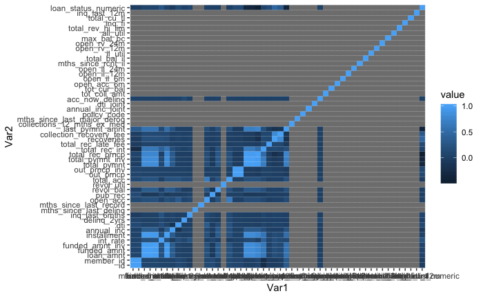

```r
ggplot(data = melted_cormat, aes(x=Var1, y=Var2, fill=value)) +
  geom_tile()
```

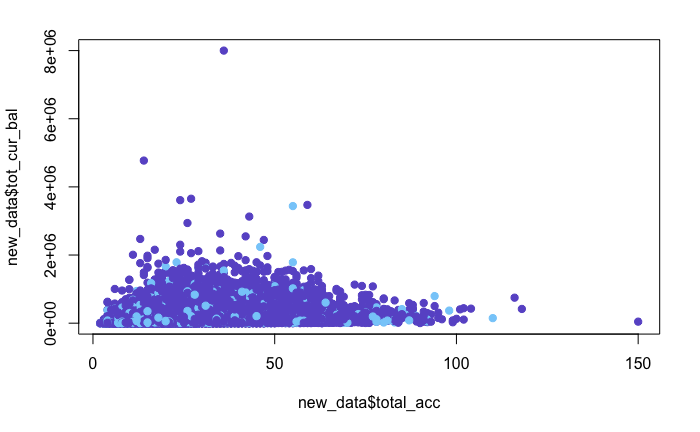

```r
plot(new_data$total_acc, new_data$tot_cur_bal, col = ifelse(new_data$loan_status == "Fully Paid", "slateblue", "lightskyblue"), pch = 19)
```

```r
missings <- numerics[,colSums(is.na(numerics)) >  nrow(numerics)*.7]
colnames(missings)
```

```
 [1] "mths_since_last_record"      "mths_since_last_major_derog" "annual_inc_joint"            "dti_joint"
 [5] "open_acc_6m"                 "open_il_6m"                  "open_il_12m"                 "open_il_24m"
 [9] "mths_since_rcnt_il"          "total_bal_il"                "il_util"                     "open_rv_12m"
[13] "open_rv_24m"                 "max_bal_bc"                  "all_util"                    "inq_fi"
[17] "total_cu_tl"                 "inq_last_12m"
```

```r
numerics2 = numerics[,-which(colnames(numerics) %in% colnames(missings))]
numerics2 = numerics2[complete.cases(numerics2),]
test_pca = prcomp(numerics2)
```

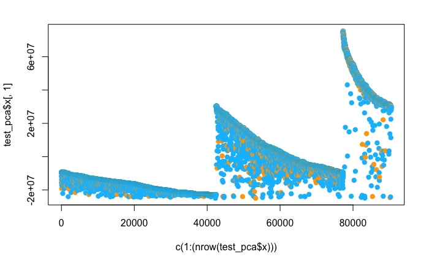

```r
plot(c(1:(nrow(test_pca$x))), test_pca$x[,1], col=ifelse(new_data$loan_status == "Fully Paid", "deepskyblue", "orange"), pch = 19)
```

```r
library(caret)
```

```r
missings <- new_data[,colSums(is.na(new_data)) >  nrow(new_data)*.7]
colnames(missings)
```

```
 [1] "mths_since_last_record"      "mths_since_last_major_derog" "annual_inc_joint"            "dti_joint"
 [5] "open_acc_6m"                 "open_il_6m"                  "open_il_12m"                 "open_il_24m"
 [9] "mths_since_rcnt_il"          "total_bal_il"                "il_util"                     "open_rv_12m"
[13] "open_rv_24m"                 "max_bal_bc"                  "all_util"                    "inq_fi"
[17] "total_cu_tl"                 "inq_last_12m"
```

```r
new_data2 = new_data[,-which(colnames(new_data) %in% colnames(missings))]
new_data2 = new_data2[complete.cases(new_data2),]
```

```r
reduced_data = new_data2[,c(3:30, ncol(new_data2))]
reduced_data$mths_since_last_delinq = NULL
#sapply(reduced_data, is.factor)
#reduced_data
fit = glm(formula = loan_status_numeric ~ ., data = reduced_data, family = "binomial")
```

```
Error in `contrasts<-`(`*tmp*`, value = contr.funs[1 + isOF[nn]]) :
  contrasts can be applied only to factors with 2 or more levels
```

```r
fit
```

```
Call:  glm(formula = loan_status_numeric ~ ., family = "binomial", data = reduced_data)

Coefficients:
    (Intercept)        loan_amnt      funded_amnt  funded_amnt_inv   term 60 months         int_rate
     -4.2578878        0.0003796       -0.0006522        0.0002461        0.3787804        0.1411769
    installment           gradeB           gradeC           gradeD           gradeE           gradeF
      0.0009207        0.5206392        0.5566494        0.4682842        0.2904736        0.0268397
         gradeG      sub_gradeA2      sub_gradeA3      sub_gradeA4      sub_gradeA5      sub_gradeB1
     -0.0578923        0.3339832        0.2507180        0.5557915        0.5119668        0.1318500
    sub_gradeB2      sub_gradeB3      sub_gradeB4      sub_gradeB5      sub_gradeC1      sub_gradeC2
     -0.0305931        0.0531178       -0.0257115               NA       -0.0052557       -0.0007691
    sub_gradeC3      sub_gradeC4      sub_gradeC5      sub_gradeD1      sub_gradeD2      sub_gradeD3
      0.0798435        0.0375662               NA        0.0877890        0.0265570       -0.0355907
    sub_gradeD4      sub_gradeD5      sub_gradeE1      sub_gradeE2      sub_gradeE3      sub_gradeE4
      0.0456980               NA        0.0386087        0.1292424        0.0898111       -0.0309138
    sub_gradeE5      sub_gradeF1      sub_gradeF2      sub_gradeF3      sub_gradeF4      sub_gradeF5
             NA       -0.0727305       -0.0176836        0.0769070       -0.0949396               NA
    sub_gradeG1      sub_gradeG2      sub_gradeG3      sub_gradeG4      sub_gradeG5
      0.0833426       -0.1515166       -0.0056141       -0.5864512               NA

Degrees of Freedom: 90450 Total (i.e. Null);  90410 Residual
Null Deviance:      87550
Residual Deviance: 82790    AIC: 82870
```

```r
grid2 = expand.grid(1, seq(0,100,by=1))
colnames(grid2) = c("alpha", "lambda")
additive_model = train(loan_status_numeric ~ .,
                   data = new_data2,
                   method = 'glmnet',
                   trControl = control,
                   tuneGrid = grid2)
```

```
Error: vector memory exhausted (limit reached?)
```

```r
m = colnames(new_data[,colSums(is.na(new_data)) >  nrow(new_data)*0])
dim(subset(new_data, select = m))
```

```
[1] 254190     24
```

```r
m
```

```
 [1] "mths_since_last_delinq"      "mths_since_last_record"      "revol_util"
 [4] "collections_12_mths_ex_med"  "mths_since_last_major_derog" "annual_inc_joint"
 [7] "dti_joint"                   "tot_coll_amt"                "tot_cur_bal"
[10] "open_acc_6m"                 "open_il_6m"                  "open_il_12m"
[13] "open_il_24m"                 "mths_since_rcnt_il"          "total_bal_il"
[16] "il_util"                     "open_rv_12m"                 "open_rv_24m"
[19] "max_bal_bc"                  "all_util"                    "total_rev_hi_lim"
[22] "inq_fi"                      "total_cu_tl"                 "inq_last_12m"
```

```r
#summary(complete_loans)
```

```r
missings <- numerics[,colSums(is.na(numerics)) >  nrow(numerics)*0]
colnames(missings)
```

```
 [1] "mths_since_last_delinq"      "mths_since_last_record"      "revol_util"                  "collections_12_mths_ex_med"
 [5] "mths_since_last_major_derog" "annual_inc_joint"            "dti_joint"                   "tot_coll_amt"
 [9] "tot_cur_bal"                 "open_acc_6m"                 "open_il_6m"                  "open_il_12m"
[13] "open_il_24m"                 "mths_since_rcnt_il"          "total_bal_il"                "il_util"
[17] "open_rv_12m"                 "open_rv_24m"                 "max_bal_bc"                  "all_util"
[21] "total_rev_hi_lim"            "inq_fi"                      "total_cu_tl"                 "inq_last_12m"
```

```r
numerics3 = numerics[,-which(colnames(numerics) %in% colnames(missings))]
numerics3 = numerics3[,-which(colnames(numerics3) == "policy_code")]
cormat <- round(cor(numerics3),2)
head(cormat)
```

```
                  id member_id loan_amnt funded_amnt funded_amnt_inv int_rate installment annual_inc  dti delinq_2yrs inq_last_6mths
id              1.00      1.00      0.07        0.08            0.08     0.05        0.05       0.04 0.12        0.06          -0.04
member_id       1.00      1.00      0.07        0.08            0.09     0.05        0.05       0.04 0.12        0.06          -0.04
loan_amnt       0.07      0.07      1.00        1.00            0.99     0.21        0.96       0.33 0.05        0.01           0.01
funded_amnt     0.08      0.08      1.00        1.00            0.99     0.21        0.96       0.33 0.05        0.01           0.01
funded_amnt_inv 0.08      0.09      0.99        0.99            1.00     0.22        0.95       0.33 0.06        0.01           0.01
int_rate        0.05      0.05      0.21        0.21            0.22     1.00        0.20      -0.03 0.17        0.09           0.22
                open_acc pub_rec revol_bal total_acc out_prncp out_prncp_inv total_pymnt total_pymnt_inv total_rec_prncp total_rec_int
id                  0.11    0.14      0.02      0.11      0.07          0.07       -0.01            0.00            0.06         -0.26
member_id           0.11    0.14      0.02      0.11      0.07          0.07       -0.01            0.00            0.06         -0.26
loan_amnt           0.20   -0.08      0.33      0.23      0.05          0.05        0.84            0.84            0.78          0.64
funded_amnt         0.20   -0.07      0.33      0.23      0.05          0.05        0.84            0.84            0.78          0.64
funded_amnt_inv     0.21   -0.07      0.33      0.23      0.05          0.05        0.84            0.84            0.78          0.63
int_rate            0.04    0.08      0.02     -0.01      0.04          0.04        0.12            0.13            0.03          0.40
                total_rec_late_fee recoveries collection_recovery_fee last_pymnt_amnt acc_now_delinq loan_status_numeric
id                           -0.04      -0.04                   -0.01            0.32           0.03               -0.03
member_id                    -0.04      -0.04                   -0.01            0.32           0.03               -0.03
loan_amnt                     0.05       0.18                    0.13            0.58           0.01                0.06
funded_amnt                   0.05       0.18                    0.13            0.58           0.01                0.06
funded_amnt_inv               0.04       0.18                    0.12            0.58           0.01                0.06
int_rate                      0.06       0.18                    0.12            0.12           0.03                0.24
```

```r
melted_cormat <- melt(cormat)
head(melted_cormat)
```

```
             Var1 Var2 value
1              id   id  1.00
2       member_id   id  1.00
3       loan_amnt   id  0.07
4     funded_amnt   id  0.08
5 funded_amnt_inv   id  0.08
6        int_rate   id  0.05
```

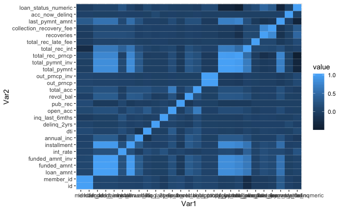

```r
ggplot(data = melted_cormat, aes(x=Var1, y=Var2, fill=value)) +
  geom_tile()
```

```r
cols_to_drop = c("id", "member_id", "url", "emp_title", "desc", "title", "mths_since_last_delinq", "mths_since_last_record", "next_pymnt_d", "verification_status_joint", "policy_code", "annual_inc_joint", "dti_joint")
new_data = new_data[, -which(colnames(new_data) %in% cols_to_drop)]
dim(new_data)
```

```
[1] 254190     62
```

*id*: This is a unique loan id local to the website, this has no impact on the loan itself. *member_id*: ID number of the user *url*: URL of the loan *emp_title*: We believe the variation of employers for each individual will be hard to gain any important information from. It is a categorical variable with tens of thousands of levels. *desc*: This is a user provided description of a loan, again, without some advanced analysis applied to the text, there is very little information we can gain from this. *title*: This is a user provided title of a loan, again, without some advanced analysis applied to the text, there is very little information we can gain from this. *mths_since_last_delinq*: Many of these values are empty, and we believe that other columns encode information about delinquencies without this level of granularity. *next_pymnt_d*: The next payment date is almost completely empty because we are considering completed loans, which have either been charged off/defaulted or paid in full. *verification_status_joint*: There is only one observation within our completed loans that indicates joint status, so we removed the columns pertaining to joint-specific accounts. *annual_inc_joint*: *dti_joint*: *policy_code*: All of the policy codes in our subset were the same.

```r
pca_colnames = c("loan_amnt", "funded_amnt", "funded_amnt_inv", "int_rate", "installment", "annual_inc", "dti", "inq_last_6mths", "mths_since_last_delinq", "mths_since_last_record", "open_acc", "revol_bal", "revol_util", "total_acc", "total_pymnt", "total_pymnt_inv", "total_rec_prncp","total_rec_int","recoveries","last_pymnt_amnt","collections_12_mths_ex_med","mths_since_last_major_derog","annual_inc_joint","dti_joint","tot_coll_amt","tot_cur_bal","open_acc_6m","open_il_6m","open_il_12m","open_il_24m","il_util","open_rv_12m","open_rv_24m","max_bal_bc","all_util","total_rev_hi_lim","inq_fi","total_cu_tl","inq_last_12m")
colnames(new_data[,-which(colnames(new_data) %in% pca_colnames)])
```

```
 [1] "term"                    "grade"                   "sub_grade"               "emp_length"              "home_ownership"
 [6] "verification_status"     "issue_d"                 "loan_status"             "pymnt_plan"              "purpose"
[11] "zip_code"                "addr_state"              "delinq_2yrs"             "earliest_cr_line"        "pub_rec"
[16] "initial_list_status"     "out_prncp"               "out_prncp_inv"           "total_rec_late_fee"      "collection_recovery_fee"
[21] "last_pymnt_d"            "last_credit_pull_d"      "application_type"        "acc_now_delinq"          "mths_since_rcnt_il"
[26] "total_bal_il"            "loan_status_numeric"
```

```r
pca_colnames[-which(pca_colnames %in% colnames(new_data))]
```

```
[1] "mths_since_last_delinq" "mths_since_last_record" "annual_inc_joint"       "dti_joint"
```

```r
#colnames(new_data[,-which(pca_colnames %in% pca_colnames)])
```

Bin date variables by year, convert to numeric: “last_credit_pull_d” “earliest_cr_line” “last_pymnt_d”

```r
new_data$last_credit_pull_yr = as.numeric(substr(new_data$last_credit_pull_d, 5,8))
new_data$earliest_cr_line_yr = as.numeric(substr(new_data$earliest_cr_line, 5,8))
new_data$last_pymnt_yr = as.numeric(substr(new_data$last_pymnt_d, 5,8))
new_data$issue_yr = as.numeric(substr(new_data$issue_d, 5,8))
```

```r
new_data$last_credit_pull_d = NULL
new_data$earliest_cr_line = NULL
new_data$last_pymnt_d = NULL
```

```r
na_colnames
```

[output not shown]

```r
#library("FactoMineR")
numerics = new_data[,sapply(new_data, is.numeric)]
dim(numerics)
```

```
[1] 254190     49
```

```r
colnames(numerics[,colSums(is.na(numerics)) > 0])
```

```
 [1] "revol_util"                  "collections_12_mths_ex_med"  "mths_since_last_major_derog"
 [4] "tot_coll_amt"                "tot_cur_bal"                 "open_acc_6m"
 [7] "open_il_6m"                  "open_il_12m"                 "open_il_24m"
[10] "mths_since_rcnt_il"          "total_bal_il"                "il_util"
[13] "open_rv_12m"                 "open_rv_24m"                 "max_bal_bc"
[16] "all_util"                    "total_rev_hi_lim"            "inq_fi"
[19] "total_cu_tl"                 "inq_last_12m"                "last_credit_pull_yr"
[22] "last_pymnt_yr"
```

```r
library("factoextra")
```

```r
na_colnames
```

```
 [1] "revol_util"                  "collections_12_mths_ex_med"  "mths_since_last_major_derog" "tot_coll_amt"                "tot_cur_bal"
 [6] "open_acc_6m"                 "open_il_6m"                  "open_il_12m"                 "open_il_24m"                 "mths_since_rcnt_il"
[11] "total_bal_il"                "il_util"                     "open_rv_12m"                 "open_rv_24m"                 "max_bal_bc"
[16] "all_util"                    "total_rev_hi_lim"            "inq_fi"                      "total_cu_tl"                 "inq_last_12m"
[21] "last_credit_pull_yr"         "last_pymnt_yr"
```

```r
summary(pca)
```

```
Call:
PCA(X = numerics_no_na, scale.unit = TRUE)


Eigenvalues
                       Dim.1   Dim.2   Dim.3   Dim.4   Dim.5   Dim.6   Dim.7   Dim.8   Dim.9  Dim.10  Dim.11
Variance               8.039   2.390   2.321   2.212   1.958   1.441   1.412   1.195   1.092   1.040   1.001
% of var.             24.360   7.242   7.034   6.702   5.933   4.366   4.279   3.620   3.308   3.151   3.032
Cumulative % of var.  24.360  31.602  38.636  45.337  51.270  55.636  59.915  63.534  66.843  69.994  73.026
                      Dim.12  Dim.13  Dim.14  Dim.15  Dim.16  Dim.17  Dim.18  Dim.19  Dim.20  Dim.21  Dim.22
Variance               0.996   0.982   0.932   0.887   0.805   0.720   0.620   0.546   0.520   0.492   0.453
% of var.              3.020   2.976   2.825   2.689   2.438   2.182   1.878   1.656   1.577   1.490   1.372
Cumulative % of var.  76.045  79.022  81.846  84.535  86.973  89.156  91.034  92.690  94.267  95.757  97.128
                      Dim.23  Dim.24  Dim.25  Dim.26  Dim.27  Dim.28  Dim.29  Dim.30  Dim.31  Dim.32  Dim.33
Variance               0.291   0.178   0.158   0.151   0.107   0.048   0.012   0.003   0.000   0.000   0.000
% of var.              0.881   0.539   0.478   0.457   0.326   0.147   0.035   0.008   0.001   0.000   0.000
Cumulative % of var.  98.009  98.548  99.026  99.484  99.809  99.956  99.991  99.999 100.000 100.000 100.000

Individuals (the 10 first)
                               Dist    Dim.1    ctr   cos2    Dim.2    ctr   cos2    Dim.3    ctr   cos2
1                          |  4.787 | -2.785  0.000  0.338 | -0.038  0.000  0.000 |  0.034  0.000  0.000 |
2                          |  7.112 | -4.399  0.001  0.383 | -2.757  0.001  0.150 | -0.261  0.000  0.001 |
3                          |  5.223 | -3.825  0.001  0.536 | -0.861  0.000  0.027 |  0.999  0.000  0.037 |
4                          |  4.046 | -0.944  0.000  0.054 | -0.269  0.000  0.004 | -0.438  0.000  0.012 |
6                          |  4.494 | -3.112  0.000  0.479 | -0.714  0.000  0.025 | -0.570  0.000  0.016 |
8                          |  5.262 | -3.548  0.001  0.455 | -1.334  0.000  0.064 |  1.167  0.000  0.049 |
9                          |  5.882 | -3.647  0.001  0.384 | -2.709  0.001  0.212 | -0.201  0.000  0.001 |
10                         |  5.534 | -4.002  0.001  0.523 | -2.866  0.001  0.268 |  0.159  0.000  0.001 |
11                         |  3.510 | -2.305  0.000  0.431 | -0.864  0.000  0.061 | -1.027  0.000  0.086 |
12                         |  3.321 | -0.137  0.000  0.002 | -1.973  0.001  0.353 | -1.276  0.000  0.148 |

Variables (the 10 first)
                              Dim.1    ctr   cos2    Dim.2    ctr   cos2    Dim.3    ctr   cos2
loan_amnt                  |  0.946 11.126  0.894 | -0.074  0.232  0.006 |  0.149  0.954  0.022 |
funded_amnt                |  0.948 11.173  0.898 | -0.067  0.191  0.005 |  0.151  0.985  0.023 |
funded_amnt_inv            |  0.947 11.161  0.897 | -0.041  0.071  0.002 |  0.157  1.065  0.025 |
int_rate                   |  0.201  0.503  0.040 |  0.163  1.115  0.027 |  0.514 11.382  0.264 |
installment                |  0.918 10.474  0.842 | -0.069  0.199  0.005 |  0.159  1.083  0.025 |
annual_inc                 |  0.414  2.130  0.171 | -0.035  0.050  0.001 | -0.299  3.853  0.089 |
dti                        |  0.082  0.084  0.007 |  0.425  7.549  0.180 |  0.011  0.005  0.000 |
delinq_2yrs                |  0.028  0.010  0.001 |  0.158  1.044  0.025 | -0.021  0.019  0.000 |
inq_last_6mths             |  0.028  0.010  0.001 |  0.051  0.109  0.003 | -0.041  0.073  0.002 |
open_acc                   |  0.296  1.088  0.087 |  0.419  7.329  0.175 | -0.438  8.275  0.192 |
```

```r
res.pca = PCA(numerics, graph = FALSE)
```

```
Missing values are imputed by the mean of the variable: you should use the imputePCA function of the missMDA package
```

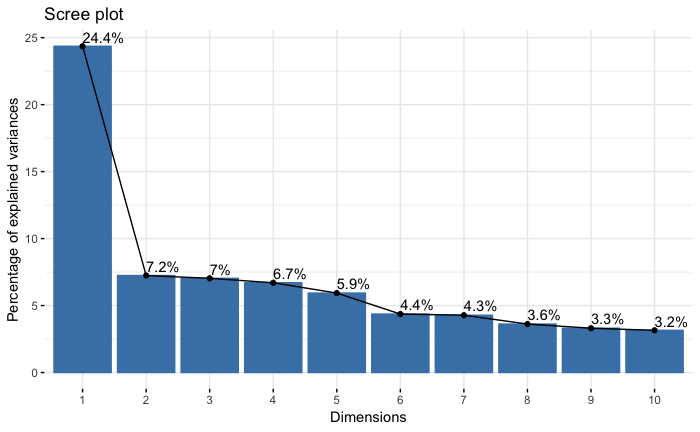

```r
fviz_eig(pca, addlabels = TRUE)
```

```r
#fviz_eig(res.pca, addlabels = TRUE)
```

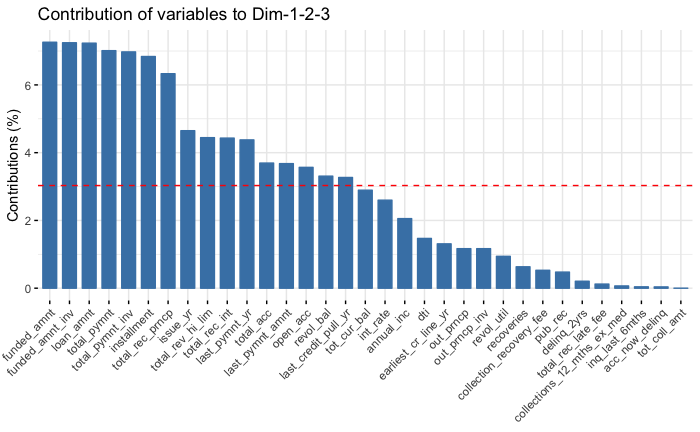

```r
contrib_colnames = fviz_contrib(pca, choice = "var", axes = 1:3)$data$name
contribs = fviz_contrib(pca, choice = "var", axes = 1:3)$data$contrib
contrib_colnames = contrib_colnames[order(contribs, decreasing = TRUE)]
contrib_colnames
```

```
 [1] funded_amnt                funded_amnt_inv            loan_amnt                  total_pymnt
 [5] total_pymnt_inv            installment                total_rec_prncp            issue_yr
 [9] total_rev_hi_lim           total_rec_int              last_pymnt_yr              total_acc
[13] last_pymnt_amnt            open_acc                   revol_bal                  last_credit_pull_yr
[17] tot_cur_bal                int_rate                   annual_inc                 dti
[21] earliest_cr_line_yr        out_prncp                  out_prncp_inv              revol_util
[25] recoveries                 collection_recovery_fee    pub_rec                    delinq_2yrs
[29] total_rec_late_fee         collections_12_mths_ex_med inq_last_6mths             acc_now_delinq
[33] tot_coll_amt
33 Levels: loan_amnt funded_amnt funded_amnt_inv int_rate installment annual_inc dti delinq_2yrs ... issue_yr
```

```r
top_15_colnames = contrib_colnames[1:15]
top_15 = numerics[,which(colnames(numerics) %in% top_15_colnames)]
top_15_colnames
```

```
 [1] funded_amnt      funded_amnt_inv  loan_amnt        total_pymnt      total_pymnt_inv  installment
 [7] total_rec_prncp  issue_yr         total_rev_hi_lim total_rec_int    last_pymnt_yr    total_acc
[13] last_pymnt_amnt  open_acc         revol_bal
33 Levels: loan_amnt funded_amnt funded_amnt_inv int_rate installment annual_inc dti delinq_2yrs ... issue_yr
```

```r
categoricals = new_data[,sapply(new_data, is.factor)]
colnames(categoricals)
```

```
 [1] "term"                "grade"               "sub_grade"           "emp_length"          "home_ownership"
 [6] "verification_status" "loan_status"         "pymnt_plan"          "purpose"             "zip_code"
[11] "addr_state"          "initial_list_status" "application_type"
```

```r
categoricals$zip_code = NULL
categoricals$application_type = NULL
#categoricals$verification_status = NULL
categoricals$loan_status = NULL
categoricals$sub_grade = NULL
categoricals$pymnt_plan = NULL
```

*zip_code*: Zip code data is too granular for our analysis, to capture locational information we can use state. *application_type*: all but one observation in our completed loans are “INDIVIDUAL”, the single observation being “JOINT”. This will not add any significant information with one observation. *sub_grade*: Sub grade data is too granular for our analysis, to capture loan quality information we can use “grade”. *pymnt_plan*: Only two observations with value “y”, the rest are “n”

```r
colnames(categoricals)
```

```
[1] "term"                "grade"               "emp_length"          "home_ownership"      "verification_status"
[6] "purpose"             "addr_state"          "initial_list_status"
```

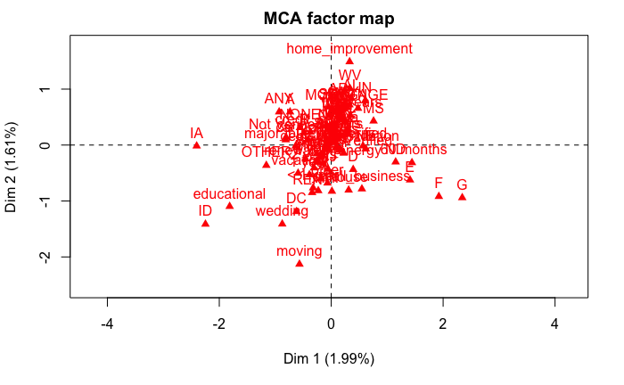

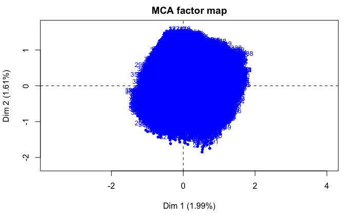

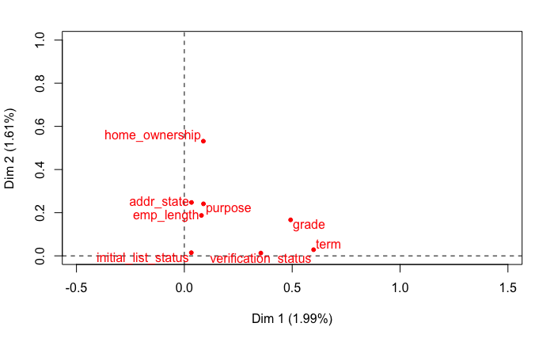

```r
mca = MCA(categoricals)
```

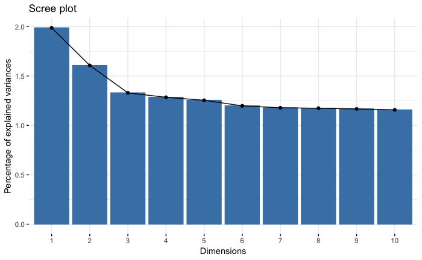

```r
fviz_eig(mca)
```

```r
summary(mca)
```

```
Call:
MCA(X = categoricals)


Eigenvalues
                       Dim.1   Dim.2   Dim.3   Dim.4   Dim.5   Dim.6   Dim.7   Dim.8   Dim.9  Dim.10  Dim.11
Variance               0.221   0.179   0.148   0.143   0.140   0.133   0.131   0.131   0.130   0.129   0.128
% of var.              1.987   1.607   1.329   1.284   1.254   1.198   1.178   1.174   1.167   1.157   1.153
Cumulative % of var.   1.987   3.594   4.923   6.208   7.462   8.660   9.838  11.011  12.178  13.335  14.489
                      Dim.12  Dim.13  Dim.14  Dim.15  Dim.16  Dim.17  Dim.18  Dim.19  Dim.20  Dim.21  Dim.22
Variance               0.128   0.128   0.128   0.128   0.127   0.127   0.127   0.127   0.127   0.127   0.127
% of var.              1.151   1.150   1.149   1.147   1.144   1.143   1.142   1.141   1.140   1.139   1.138
Cumulative % of var.  15.640  16.789  17.939  19.086  20.230  21.373  22.515  23.657  24.797  25.936  27.073
                      Dim.23  Dim.24  Dim.25  Dim.26  Dim.27  Dim.28  Dim.29  Dim.30  Dim.31  Dim.32  Dim.33
Variance               0.126   0.126   0.126   0.126   0.126   0.126   0.126   0.126   0.125   0.125   0.125
% of var.              1.137   1.136   1.136   1.134   1.133   1.132   1.131   1.129   1.127   1.127   1.126
Cumulative % of var.  28.210  29.346  30.482  31.616  32.749  33.880  35.011  36.141  37.268  38.395  39.521
                      Dim.34  Dim.35  Dim.36  Dim.37  Dim.38  Dim.39  Dim.40  Dim.41  Dim.42  Dim.43  Dim.44
Variance               0.125   0.125   0.125   0.125   0.125   0.125   0.125   0.125   0.125   0.125   0.125
% of var.              1.125   1.125   1.125   1.124   1.124   1.124   1.124   1.124   1.124   1.124   1.124
Cumulative % of var.  40.646  41.771  42.895  44.019  45.143  46.267  47.391  48.514  49.638  50.761  51.885
                      Dim.45  Dim.46  Dim.47  Dim.48  Dim.49  Dim.50  Dim.51  Dim.52  Dim.53  Dim.54  Dim.55
Variance               0.125   0.125   0.125   0.125   0.125   0.125   0.125   0.125   0.125   0.125   0.125
% of var.              1.124   1.124   1.124   1.124   1.124   1.124   1.123   1.122   1.121   1.121   1.120
Cumulative % of var.  53.009  54.132  55.256  56.379  57.503  58.627  59.750  60.871  61.993  63.114  64.234
                      Dim.56  Dim.57  Dim.58  Dim.59  Dim.60  Dim.61  Dim.62  Dim.63  Dim.64  Dim.65  Dim.66
Variance               0.124   0.124   0.124   0.124   0.124   0.124   0.124   0.124   0.124   0.124   0.123
% of var.              1.119   1.118   1.117   1.117   1.115   1.115   1.113   1.113   1.111   1.111   1.109
Cumulative % of var.  65.353  66.471  67.588  68.705  69.820  70.935  72.048  73.160  74.272  75.382  76.491
                      Dim.67  Dim.68  Dim.69  Dim.70  Dim.71  Dim.72  Dim.73  Dim.74  Dim.75  Dim.76  Dim.77
Variance               0.123   0.123   0.123   0.123   0.123   0.122   0.122   0.122   0.122   0.122   0.121
% of var.              1.108   1.107   1.106   1.105   1.104   1.100   1.100   1.099   1.096   1.093   1.091
Cumulative % of var.  77.599  78.706  79.812  80.917  82.022  83.122  84.222  85.321  86.416  87.509  88.600
                      Dim.78  Dim.79  Dim.80  Dim.81  Dim.82  Dim.83  Dim.84  Dim.85  Dim.86  Dim.87  Dim.88
Variance               0.121   0.120   0.119   0.119   0.118   0.114   0.112   0.111   0.107   0.089   0.080
% of var.              1.088   1.082   1.072   1.069   1.057   1.027   1.006   0.995   0.961   0.802   0.719
Cumulative % of var.  89.689  90.770  91.843  92.912  93.969  94.995  96.001  96.996  97.957  98.759  99.478
                      Dim.89
Variance               0.058
% of var.              0.522
```

[output cut: 34 more lines]

```
E            27.697 |
F            83.303 |
G            70.539 |
< 1 year    -19.398 |

Categorical variables (eta2)
                      Dim.1 Dim.2 Dim.3
term                | 0.599 0.029 0.001 |
grade               | 0.493 0.167 0.146 |
emp_length          | 0.079 0.187 0.114 |
home_ownership      | 0.088 0.531 0.060 |
verification_status | 0.355 0.013 0.125 |
purpose             | 0.089 0.241 0.365 |
addr_state          | 0.033 0.247 0.122 |
initial_list_status | 0.032 0.015 0.251 |
```

```r
colnames(categoricals)
```

[output not shown]

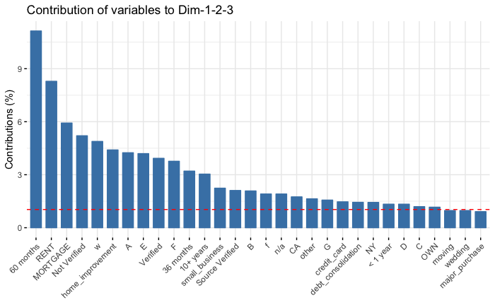

```r
colnames(model_1_data)
```

```
 [1] "loan_amnt"           "funded_amnt"         "funded_amnt_inv"     "term"                "installment"
 [6] "grade"               "emp_length"          "home_ownership"      "verification_status" "purpose"
[11] "addr_state"          "open_acc"            "revol_bal"           "total_acc"           "initial_list_status"
[16] "total_pymnt"         "total_pymnt_inv"     "total_rec_prncp"     "total_rec_int"       "last_pymnt_amnt"
[21] "total_rev_hi_lim"    "last_pymnt_yr"       "issue_yr"
```

```r
library(glmnet)
```

```r
colSums(is.na(model_1_data))
```

```
          loan_amnt         funded_amnt     funded_amnt_inv                term         installment
                  0                   0                   0                   0                   0
              grade          emp_length      home_ownership verification_status             purpose
                  0                   0                   0                   0                   0
         addr_state            open_acc           revol_bal           total_acc initial_list_status
                  0                   0                   0                   0                   0
        total_pymnt     total_pymnt_inv     total_rec_prncp       total_rec_int     last_pymnt_amnt
                  0                   0                   0                   0                   0
   total_rev_hi_lim       last_pymnt_yr            issue_yr
              63726                 536                   0
```

```r
model_1_data$total_rev_hi_lim = NULL
model_1_data$last_pymnt_yr[is.na(model_1_data$last_pymnt_yr)] = mean(model_1_data$last_pymnt_yr, na.rm=TRUE)
```

```r
which(is.na(as.matrix(model_1_data)))
```

```
integer(0)
```

```r
test_idx = sample(1:nrow(model_1_data),size = .2 * nrow(model_1_data))
test = model_1_data[test_idx,]
train = model_1_data[-test_idx,]
#model_1_data$loan_status_numeric = new_data$loan_status_numeric
#cv_fit_1 = cv.glmnet(model_1_data, new_data$loan_status_numeric, nfolds = 5)
cv_fit_1 = glm(loan_status_numeric~., family = "binomial", data = train)
```

```
Error in eval(family$initialize) : y values must be 0 <= y <= 1
```

```r
summary(cv_fit_1)
```

```
Call:
glm(formula = loan_status_numeric ~ ., family = "binomial", data = train)

Deviance Residuals:
    Min       1Q   Median       3Q      Max
-5.6126  -0.0075   0.0000   0.0000   8.4904

Coefficients:
                                     Estimate Std. Error z value Pr(>|z|)
(Intercept)                         9.275e+01  2.401e+03   0.039  0.96918
loan_amnt                           5.762e-05  7.456e-05   0.773  0.43968
funded_amnt                         7.907e-03  7.298e-04  10.835  < 2e-16 ***
funded_amnt_inv                    -5.335e-03  7.124e-04  -7.489 6.95e-14 ***
term 60 months                      4.855e-01  2.997e-01   1.620  0.10519
installment                         5.169e-03  2.133e-03   2.423  0.01539 *
gradeB                              2.661e-01  1.278e-01   2.082  0.03731 *
gradeC                              3.988e-01  1.377e-01   2.897  0.00377 **
gradeD                              4.431e-01  1.604e-01   2.763  0.00572 **
gradeE                              2.581e-01  2.326e-01   1.109  0.26723
gradeF                              4.660e-02  3.650e-01   0.128  0.89840
gradeG                              5.381e-01  6.488e-01   0.829  0.40689
emp_length1 year                    1.354e-01  1.957e-01   0.692  0.48881
emp_length10+ years                 2.442e-01  1.621e-01   1.506  0.13196
emp_length2 years                   2.757e-01  1.817e-01   1.517  0.12928
emp_length3 years                   4.798e-03  1.950e-01   0.025  0.98037
emp_length4 years                   7.472e-02  2.030e-01   0.368  0.71282
emp_length5 years                   1.465e-02  2.055e-01   0.071  0.94314
emp_length6 years                   4.829e-02  2.278e-01   0.212  0.83213
emp_length7 years                   3.768e-01  2.198e-01   1.714  0.08651 .
emp_length8 years                   2.717e-01  2.422e-01   1.122  0.26205
emp_length9 years                   1.811e-01  2.661e-01   0.681  0.49596
emp_lengthn/a                       9.845e-01  1.921e-01   5.125 2.98e-07 ***
home_ownershipMORTGAGE              4.882e-04  2.400e+03   0.000  1.00000
home_ownershipNONE                 -1.048e+01  2.424e+03  -0.004  0.99655
home_ownershipOTHER                 5.084e-01  2.400e+03   0.000  0.99983
home_ownershipOWN                  -1.809e-01  2.400e+03   0.000  0.99994
home_ownershipRENT                 -1.818e-01  2.400e+03   0.000  0.99994
verification_statusSource Verified -2.345e-01  1.046e-01  -2.242  0.02499 *
verification_statusVerified        -1.102e-01  1.024e-01  -1.077  0.28146
purposecredit_card                  1.028e-02  2.577e-01   0.040  0.96820
```

[output cut: 68 more lines]

```
total_rec_prncp                    -8.124e-02  2.977e-03 -27.292  < 2e-16 ***
total_rec_int                      -7.777e-02  2.976e-03 -26.132  < 2e-16 ***
last_pymnt_amnt                    -2.664e-03  5.514e-05 -48.315  < 2e-16 ***
last_pymnt_yr                      -4.979e-01  5.363e-02  -9.284  < 2e-16 ***
issue_yr                            4.505e-01  4.857e-02   9.275  < 2e-16 ***
---
Signif. codes:  0 ‘***’ 0.001 ‘**’ 0.01 ‘*’ 0.05 ‘.’ 0.1 ‘ ’ 1

(Dispersion parameter for binomial family taken to be 1)

    Null deviance: 193655.8  on 203351  degrees of freedom
Residual deviance:   5174.4  on 203248  degrees of freedom
AIC: 5382.4

Number of Fisher Scoring iterations: 15
```